# Estimation of Direct and Indirect Storage, Ramuschaka

Edward Davis

2/19/2019

### Libraries used

```r
library(tidyverse)
library(readxl)
library(lubridate)
library(padr)
library(scales)
library(sirad)
library(pracma)
library(gt)
```

### Data import and basic tidying

```r
# Import data
ramu_precip <- read_excel("data/upper-middle.xlsx", sheet = "precip_update",
                          skip = 1)
ramu_stage <- read_excel("data/upper-middle.xlsx", sheet = "stage_update",
                         skip = 1)

# Data tidying
upper_middle <- ramu_precip %>%
  right_join(ramu_stage, by = "Date Time, GMT-05:00") %>%
  rename(date_time = `Date Time, GMT-05:00`,
         air_temp = `Temp, Â°C (LGR S/N: 20381067, SEN S/N: 20381067, LBL: T)`,
         water_level_m = `Sensor Depth (m)`,
         q_est = `Q est m3/s`,
         precip_mm = `mm of rain`) %>%
  select(date_time, air_temp, precip_mm, water_level_m, q_est) %>%
  filter(!is.na(water_level_m))

# Display first few rows of tidied data
head(upper_middle) %>% gt()
```

| date_time | air_temp | precip_mm | water_level_m | q_est |
| --- | --- | --- | --- | --- |
| 2018-10-01 00:00:00 | 4.623 | 0 | 0.125 | 0.003282812 |
| 2018-10-01 00:15:00 | 4.102 | 0 | 0.125 | 0.003282812 |
| 2018-10-01 00:30:00 | 3.367 | 0 | 0.124 | 0.002973803 |
| 2018-10-01 00:45:00 | 3.683 | 0 | 0.125 | 0.003282812 |
| 2018-10-01 01:00:00 | 3.893 | 0 | 0.123 | 0.002663373 |
| 2018-10-01 01:15:00 | 3.472 | 0 | 0.125 | 0.003282812 |

# Recession Analysis

### Smoothing gage data

Here, I resample the data for hourly values, and smooth the discharge using a 72-hour moving average:

```r
cms_to_mm <- function(x, wshd_area, duration){
# wshd_area in km2
# duration in sec
  x * duration / (wshd_area * 1e6) * 1000
}

# Resample data set for daily values
daily_upper_middle <- upper_middle %>%
  thicken("day", colname = "date") %>%
  group_by(date) %>%
  summarise(mean_daily_prcp = sum(precip_mm),
            mean_daily_prcp = ifelse(is.na(mean_daily_prcp),
                                     0, mean_daily_prcp),
            mean_daily_q = mean(q_est, na.rm = TRUE),
            mean_daily_q_mm = cms_to_mm(mean_daily_q, 0.77, 86400),
            mean_daily_t = mean(air_temp, na.rm = TRUE))

# Resample data set for hourly values
hourly_upper_middle <- upper_middle %>%
  thicken("hour", colname = "dt_hour") %>%
  group_by(dt_hour) %>%
  summarise(hourly_q = mean(q_est, na.rm = TRUE),
            hourly_q_mm = cms_to_mm(hourly_q, 0.77, 3600),
            hourly_p = sum(precip_mm, na.rm = TRUE),
            hourly_t = mean(air_temp, na.rm = TRUE)) %>%
  mutate(row_id = seq(1, length(hourly_q_mm)),
         movavg_q = movavg(hourly_q_mm, 72, type = "s"))
```

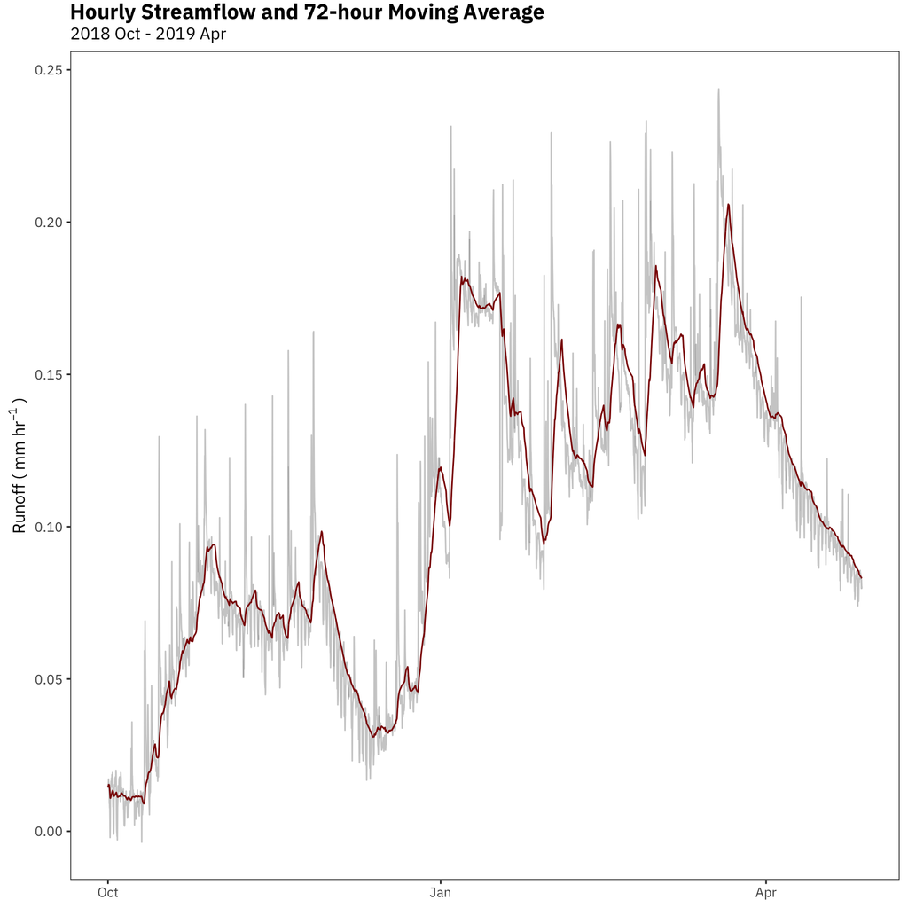

### Extracting recession limbs

Loop to find recession limbs that fit the criteria:

1. No significant (> 0.002 mm) rainfall in the past 24 hours
2. A decreasing Q

```r
recess_extract <- function(q, p, start_row = 1) {
  # Counter variable — starts after 72-hr moving average begins
  i <- start_row

  # Dummy data frame to hold row ID
  row_id <- rep(NA, nrow(hourly_upper_middle))

  # Begin looping over hourly Q and P data
  while(i < nrow(hourly_upper_middle) - 1){
    # Select rows that have < 0.002 mm 24-hour antecedent rainfall and have decreasing Q
    if(mean(p[c(i - 24, i)]) < 0.002 & q[i] < q[i - 1]) {

      row_id[i] <- i
      i <- i + 1
    } else {
      i <- i + 1
    }

  }
  row_id <<- data.frame(row_id = row_id[!is.na(row_id)])
}

recess_extract(hourly_upper_middle$movavg_q, hourly_upper_middle$hourly_p, start_row = 25)
```

### Filtering recession data

Here, I narrow the data down to rainless recessions with a duration of 24 hours or more.

```r
recession_limbs <- hourly_upper_middle %>%
  right_join(row_id)

dates1 <- recession_limbs$dt_hour
df1 <- data.frame(dates1, group = cumsum(c(TRUE, diff(dates1) != 1)))

recession_limbs <- df1 %>%
  mutate(dt_hour = as_datetime(dates1)) %>%
  left_join(recession_limbs)

consec_events <- recession_limbs %>%
  group_by(group) %>%
  tally() %>%
  filter(n >= 24) %>%
  pull(group)

recession_limbs <- recession_limbs %>%
  filter(group %in% consec_events) %>%
  select(dt_hour, q = movavg_q, group, row_id)
```

Narrowing the data resulted in the extraction of 19 recession periods:

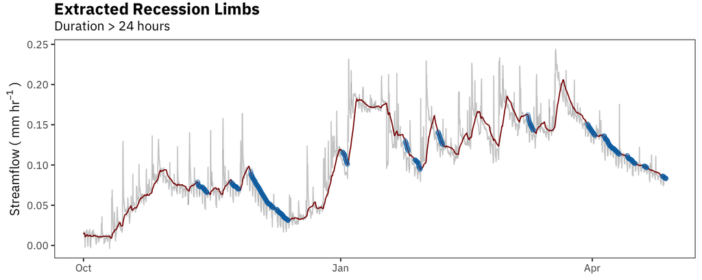

### Variable timestep, after Palmroth, et al. (2010)

Application of variable timestep, using a threshold of $0.001\overline{Q}$ where $\overline{Q}$ is the mean hourly discharge over the entire dataset:

```r
threshold <- mean(hourly_upper_middle$movavg_q, na.rm = TRUE) * 0.001

# Timestep of 1 hour
one_hour_groups <- recession_limbs %>%
  group_by(group) %>%
  mutate(q_diffs = lag(q, 1) - q) %>%
  filter(q_diffs < threshold) %>%
  tally(group) %>%
  select(group) %>%
  pull()

one_hour_step <- recession_limbs %>%
  filter(!(group %in% one_hour_groups)) %>%
  mutate(dt = 1)

reject_groups <- one_hour_groups
# Timestep of 2 hours
two_hour_groups <- recession_limbs %>%
  group_by(group) %>%
  filter(group %in% one_hour_groups,
         row_number() %% 2 == 0) %>%
  mutate(q_diffs = lag(q, 1) - q) %>%
  filter(q_diffs < threshold) %>%
  tally(group) %>%
  select(group) %>%
  pull()

two_hour_step <- recession_limbs %>%
  filter(!(group %in% two_hour_groups) & group %in% one_hour_groups,
         row_number() %% 2 == 0) %>%
  mutate(dt = 2)

reject_groups <- c(reject_groups, two_hour_groups)

# Timestep of 3 hours
three_hour_groups <- recession_limbs %>%
  group_by(group) %>%
  filter(group %in% reject_groups,
         row_number() %% 3 == 1) %>%
  mutate(q_diffs = lag(q, 1) - q) %>%
  filter(q_diffs < threshold) %>%
  tally(group) %>%
  select(group) %>%
  pull()

three_hour_step <- recession_limbs %>%
  filter(!(group %in% three_hour_groups) & group %in% two_hour_groups,
         row_number() %% 3 == 1) %>%
  mutate(dt = 3)

reject_groups <- c(reject_groups, three_hour_groups)

# Timestep of 4 hours
four_hour_groups <- recession_limbs %>%
  group_by(group) %>%
  filter(group %in% reject_groups,
         row_number() %% 4 == 1) %>%
  mutate(q_diffs = lag(q, 1) - q) %>%
  filter(q_diffs < threshold) %>%
  tally(group) %>%
  select(group) %>%
  pull()

four_hour_step <- recession_limbs %>%
  filter(!(group %in% four_hour_groups) & group %in% three_hour_groups,
         row_number() %% 4 == 1) %>%
  mutate(dt = 4)
```

### Numerical differentiation

Estimating $\frac{dQ}{dt}$ and binning values for averaging:

```r
# Ready data for numerical derivatives
timestepped_recessions <- one_hour_step %>%
  bind_rows(two_hour_step, three_hour_step, four_hour_step) %>%
  arrange(dt_hour)

# Estimating dq_dt using central difference, after Palmroth, et al. (2010)
dq_dt <- timestepped_recessions %>%
  group_by(group) %>%
  mutate(dq = (lead(q, 1) - lag(q, 1)) / (2 * dt),
         q = lead(q, 1) + lag(q, 1) / 2,
         log_dq = log(abs(dq)),
         log_q = log(q)) %>%
  ungroup() %>%
  filter(!(is.na(dq))) %>%
  arrange(desc(q)) %>%
  select(dq, q, log_dq, log_q)


# Kirchner (2009) style binning - "Irregular Binning Method"
log_q_range <- dq_dt %>%
  summarise(log_q_range = 0.01 * (min(log_q) - max(log_q))) %>%
  pull()

bins <- c(1)

for(r in seq(1, nrow(dq_dt) - 1)) {

  loud = F
  min_per_bin = 45 # Chosen to improve fit of linear regression

  # Testing to make sure values are in set range
  if(dq_dt$log_q[r + 1] - dq_dt$log_q[r] < log_q_range){
    if(loud){print("Bin too small")}
    next
  }
  # Testing to make sure bins are larger than min_per_bin value
  if(abs(r - bins[length(bins)]) < min_per_bin){
    if(loud){print("Not enough data points")}
    next
  }
  # Testing for bin heterogeneity
  curr = dq_dt$dq[c((bins[length(bins)]), (r + 1))]

  if(sd(-1 * curr) / sqrt(abs(r - bins[length(bins)])) > mean(-1 * curr)/2){
    if(loud){print("Bin too heterogenous")}
    next
  }
  bins <- c(bins, r)
}

# Binning data based on output from above loop
binned <- dq_dt %>%
  arrange(desc(log_q)) %>%
  mutate(id = row_number(),
         category = cut(id, breaks= bins, right = FALSE,
                      labels=seq(1, (length(bins)-1)))) %>%
  group_by(category) %>%
  mutate(mean_dq = mean(abs(dq)),
         se = sqrt(var(log_dq)/length(log_dq)),
         weights = 1 / sqrt(se)) %>%
  summarise(mean_dq = mean(-1 * dq),
            mean_q = mean(q),
            log_q = mean(log_q),
            log_dq = mean(log_dq),
            weights = max(weights),
            se = max(se))
```

### Weighted linear regression

I fit a quadratic curve to the binned data using a weighted linear regression, where the weights were equal to $\frac{1}{\sqrt{std. error}}$ for each binned $\log(-dQ/dt)$.

```r
# Weighted linear regression
model <- lm(binned$log_dq ~ poly(binned$log_q, 2),
            weights = binned$weights)

# Capture parameters and R squared from model
p0 <- number(model$coefficients[[1]], accuracy = 0.0001)
p1 <- number(model$coefficients[[2]], accuracy = 0.0001)
p2 <- number(model$coefficients[[3]], accuracy = 0.0001)
r_sq <- number(summary(model)$r.squared, accuracy = 0.001)

summary(model)
```

```
##
## Call:
## lm(formula = binned$log_dq ~ poly(binned$log_q, 2), weights = binned$weights)
##
## Weighted Residuals:
##     Min      1Q  Median      3Q     Max
## -0.6010 -0.1350 -0.0699  0.2245  0.5245
##
## Coefficients:
##                        Estimate Std. Error  t value Pr(>|t|)
## (Intercept)            -8.39556    0.05871 -143.006 6.39e-15 ***
## poly(binned$log_q, 2)1  0.74364    0.18780    3.960  0.00418 **
## poly(binned$log_q, 2)2  0.03992    0.19490    0.205  0.84282
## ---
## Signif. codes:  0 '***' 0.001 '**' 0.01 '*' 0.05 '.' 0.1 ' ' 1
##
## Residual standard error: 0.3909 on 8 degrees of freedom
## Multiple R-squared:  0.6643, Adjusted R-squared:  0.5804
## F-statistic: 7.915 on 2 and 8 DF,  p-value: 0.0127
```

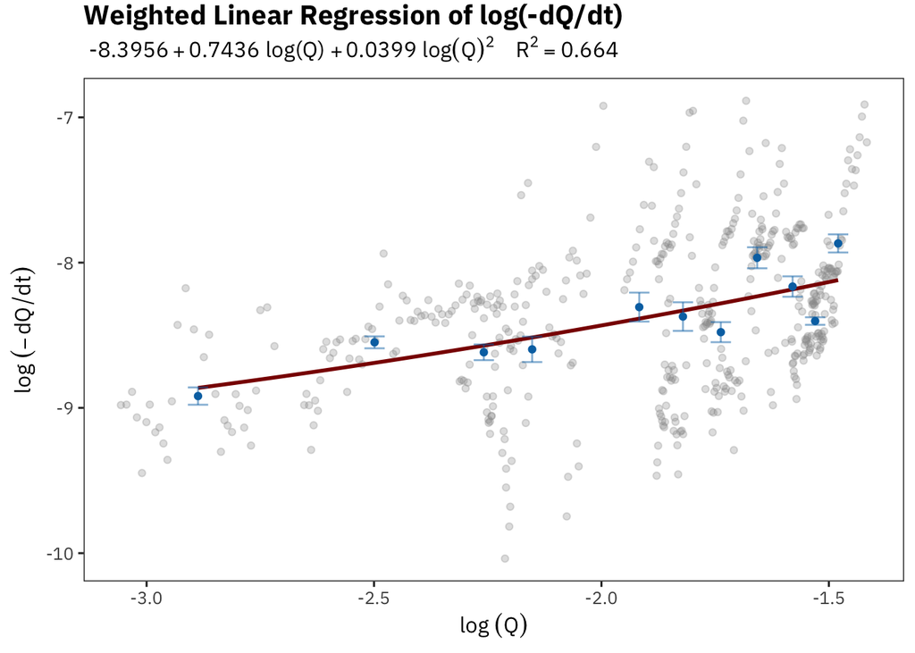

### Sensitivity function

The general sensitivity function $g(Q)$ follows the form:
$$g(Q) = \log\bigg(\frac{dQ/dt}{Q}\bigg) = p_0+(p_1 - 1) \log(Q) +p_2\log(Q)^2$$

```r
p0 <- model$coefficients[[1]]
p1 <- model$coefficients[[2]]
p2 <- model$coefficients[[3]]

g <- function(q, p0, p1, p2){
  g <- p0 + ((p1 - 1) * log(q)) + (p2 * (log(q)^2))
  return(g)
}
```

# Estimating Evapotranspiration

I compute $E_p$ using the Hargreaves equation after Dralle et al, (2017) and Allen, Peirera, Raes and Smith (1998):

Daily $R_{est}$ was calculated using the `extrat()` function in the `sirad` package by Jedrzej S. Bojanowski, which uses the same methods described in Allen, et al. (1998).

```r
zurite_lat <- -13.439

E_p <- hourly_upper_middle %>%
  mutate(julian = yday(dt_hour),
         date = date(dt_hour)) %>%
  group_by(julian) %>%
  mutate(r_est = extrat(julian, zurite_lat)[[1]],
         E_p = 0.0023 * (max(hourly_t) + 17.8) * ((max(hourly_t) - min(hourly_t)) ^ 0.5) * 0.408 * r_est) %>%
  summarise(date = mean(date), r_est = mean(r_est),
            E_p = mean(E_p)) %>%
  arrange(date)

head(E_p) %>% gt()
```

| julian | date | r_est | E_p |
| --- | --- | --- | --- |
| 274 | 2018-10-01 | 27.51704 | 4.834698 |
| 275 | 2018-10-02 | 27.85779 | 5.049254 |
| 276 | 2018-10-03 | 28.19647 | 5.156693 |
| 277 | 2018-10-04 | 28.53299 | 2.566543 |
| 278 | 2018-10-05 | 28.86723 | 3.828743 |
| 279 | 2018-10-06 | 29.19909 | 4.304372 |

# Determining $S_d$ and $S_i$

### Numerical integration

```r
q <- daily_upper_middle$mean_daily_q_mm

direct_s <- function(q) {
  num <- lag(q, 1) - q
  num <- num[-1]
  denom <- g(q, p0, p1, p2)
  denom <- denom[-1]

  x <- seq(1, length(num))
  y <- num / denom

  s_d <- c(0)
  int <- cumtrapz(x, y)

  s_d <- c(s_d, int)
  return(s_d)
}
```

### Cumulative values and calculation of $S_i$

```r
direct_indirect <- daily_upper_middle %>%
  right_join(E_p, by = "date") %>%
  add_column(d_s = direct_s(q)) %>%
  # If d_s < 0, I assume that it is = 0
  mutate(d_s = ifelse(d_s < 0, 0, d_s),
         cum_q = cumsum(mean_daily_q_mm) - mean_daily_q_mm[1],
         cum_p = cumsum(mean_daily_prcp),
         i_s = cum_p - cum_q - E_p - d_s,
         # Make E_p = 0 if i_s is negative
         E_p = ifelse(i_s <=0, 0, E_p),
         i_s = cum_p - cum_q - E_p - d_s,
         # Make negative i_s = zero
         i_s = ifelse(i_s < 0, 0, i_s),
         total = cum_p - cum_q - E_p,
         # Make negative total = zero
         total = ifelse(total < 0, 0 , total)) %>%
  select(date, mean_daily_q_mm, cum_p, cum_q, d_s, i_s, total, E_p)
```

### Plot of final results

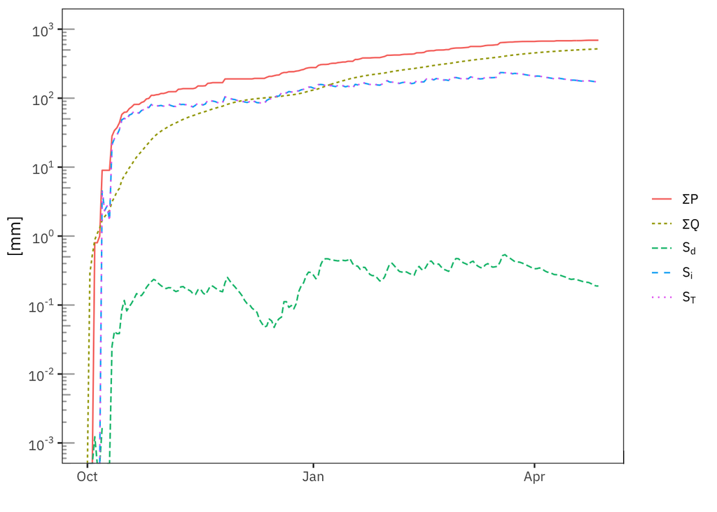

```r
summary <- direct_indirect %>%
  mutate(cum_et = cumsum(E_p)) %>% gt()
```